# Session 9 - Web Scraping (2)

26. Juni 2018

## Syllabus

Session 1 - R and RStudio

Session 2 - Data Typen und erste Befehle

Session 3 - Daten einlesen und speichern

Session 4 - Einfache Analyse (numerisch)

Session 5 - Visualisierung

Session 6 & 7 - Application Programming Interfaces (APIs)

`Session 8 & 9 - Introduction to Web Scraping`

## Agenda

1. HTML, Klassen und IDs
2. Scraping mit rvest
3. Selector Gadget
4. Aufgaben
5. Recap - Was wir jetzt können?
6. Danke !

## Hausaufgaben besprechen

## HTML, Klassen und IDs

```html
<h2 class="city" id="favoriteCity">London</h2>
<p class="description">London is the capital of England.</p>
<h2 class="city">Paris</h2>
<p class="description">Paris is the capital of France.</p>
```

## Scraping mit rvest (1)

```r
# Paket laden
library(rvest)
# HTML einlesen (kann auch eine URL sein)
cities <- read_html(cities)
# Namen parsen
city_names <- html_nodes(cities, ".city")
city_names <- html_text(city_names)
# Beschreibung parsen
city_description <- html_nodes(cities, ".description")
city_description <- html_text(city_description)
```

```
##     name                       description
## 1 London London is the capital of England.
## 2  Paris   Paris is the capital of France.
```

## Scraping mit rvest (2)

```r
# Lieblingsstadt parsen
favorite_city <- html_nodes(cities, "#favoriteCity")
favorite_city <- html_text(favorite_city)
```

```
## [1] "London"
```

## Selector Gadget

SelectorGadget is an open source tool that makes CSS selector generation and discovery on complicated sites a breeze. (Selector Gadget, 2018)

https://selectorgadget.com/

## Scraping mit rvest (3)

```r
# HTML herunterladen
lego_movie <- read_html("http://www.imdb.com/title/tt1490017/")
# Cast parsen
cast <- html_nodes(lego_movie, "#titleCast .itemprop span")
cast <- html_text(cast)
```

```
##  [1] "Will Arnett"     "Elizabeth Banks" "Craig Berry"
##  [4] "Alison Brie"     "David Burrows"   "Anthony Daniels"
##  [7] "Charlie Day"     "Amanda Farinos"  "Keith Ferguson"
## [10] "Will Ferrell"    "Will Forte"      "Dave Franco"
## [13] "Morgan Freeman"  "Todd Hansen"     "Jonah Hill"
```

## Aufgaben

1. Lade den Datensatz `nyt_articles.rds`. Diesen haben wir mit Hilfe der NYT API heruntergeladen und enthält mögliche Zeitungsartikel zu Anschlägen.
2. Lade die Artikel nun herunter. Scrape die Artikeltexte und speicher alle Artikel in einem Vektor `articles`. (Tipp: `c()`)
3. Lade die Funktion `nyt_wordcloud()` aus dem Script `nyt_wordcloud.R` (`source()`). Nutzte die Funktion, um eine Wordcloud zu erstellen.

## Recap

## Road Map

[figure not shown]

## Was könnt ihr jetzt? - Basics (1):

- Basaler Umgang mit GIT
- CSV/EXCEL/JSON einlesen
- Daten speichern
- Einfache Konzepte der Programmierung (Ifelse, Loop)
- Einfache Deskriptive Analyse mit R
- Einfache Plots mit R

## Was könnt ihr jetzt? - Fancy S*** (2)

- Interaktion mit unterschiedlichsten API's
- Nie wieder Daten von Hand kopieren (htmltab)
- Webseiten scrapen

## Weiterführende Ideen - Was ist möglich (1) ?

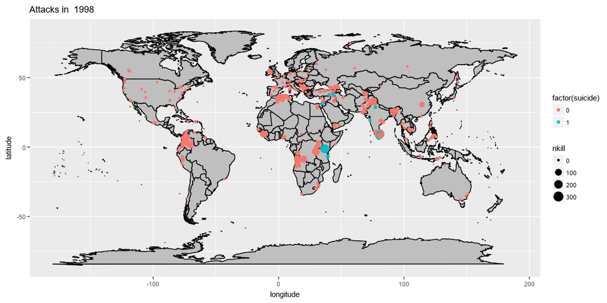

## Weiterführende Ideen - Was ist möglich (2)?

[interactive chart not shown]

## Vielen Dank!

Vielen Dank für Eure regelmäßige Teilnahme. Wir würden uns freuen, wenn ihr alle die Umfrage ausfühlt, die wir Euch via Twitter zukommen lassen.

## Weiterführende Links

### Programmieren üben

- [DataCamp](https://www.datacamp.com/)
- [Kaggle](https://www.kaggle.com/)
- [R Bloggers](https://www.r-bloggers.com/)
- [Codecademy](https://www.codecademy.com/)

### Weiterführende Literatur

- [R for Data Science](http://r4ds.had.co.nz/)
- [Text Mining with R](https://www.tidytextmining.com/)
- [R Packages](http://r-pkgs.had.co.nz/)
- [Advanced R](http://adv-r.had.co.nz/)